# Multiple Regression

Predicting Reading Achievement

```r
library(arm)
library(texreg)
```

After building an intuitive understanding of simple regression we will now expand our model to include more than one predictor. But keep this as simple as possible, I will focus mostly on models with two predictors.

First, let’s expand the simple regression equation to accommodate multiple predictors. Equation 1 below is the simple regression equation for the sample.

$$Y_i = a + b X_i + e_i \tag{1}$$
Here $Y_i$ is the value on the outcome variable for the $i$th subject, while $X_i$ is the value of the predictor variable for the same subject. The estimated parameters $a$ and $b$ are the intercept and slope for $X$, which are common for the whole sample (e.g. we only estimate one intercept and one slope that is constant across all individual). The $e_i$ is the $i$th subjects residual, or the difference between their model predicted score and their observed score.

To expand this we need to add more predictors and be able to distinguish them.

$$Y_i = a + b_1 X_{1i} + b_2 X_{2i} + ...+ b_k X_{ki} + e_i \tag{2}$$
This is done, as in equation 2, by adding numeric subscripts to the slope coefficients, and to the predictors. Note that equation 2 is generic and can accommodate any number of predictors ($k$).

## Reading Achievement Model

In this post I will build on what we covered related to simple regression by introducing multiple regression. In this post I will use data from Pedhazur (1997), chapter 5, table 1 to model the use of verbal aptitude and achievement motivation to predict reading achievement.

I will use the following packages in this tutorial:

```r
library(psych)
library(arm)
library(texreg)
```

Below is R code to create a data frame from the data in the book.

```r
dat51 <- data.frame(
  readAch  = c(2, 4, 4, 1, 5, 4, 7, 9, 7, 8, 5, 2, 8, 6, 10, 9, 3, 6, 7, 10),
  verbalApt = c(1, 2, 1, 1, 3, 4, 5, 5, 7, 6, 4, 3, 6, 6, 8, 9, 2, 6, 4, 4),
  achMot = c(3, 5, 3, 4, 6, 5, 6, 7, 8, 4, 3, 4, 6, 7, 7, 6, 6, 5, 6, 9)
)
```

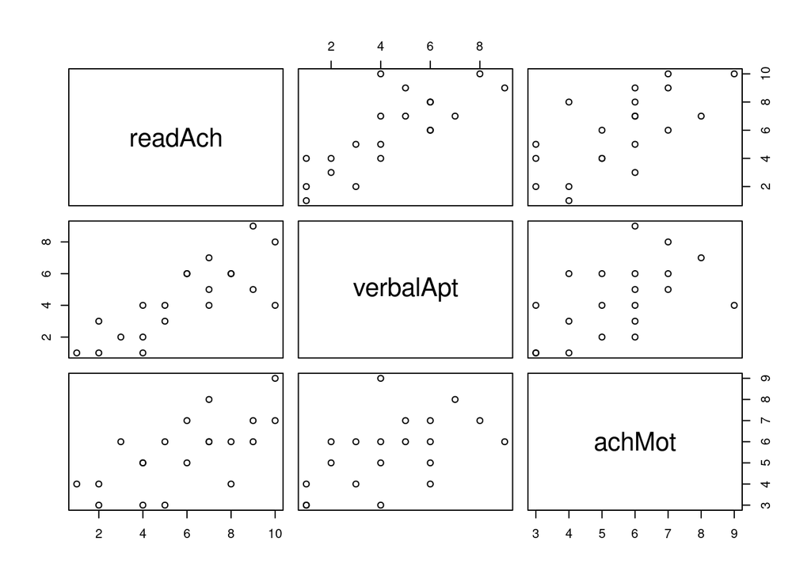

```r
pairs(dat51)
```

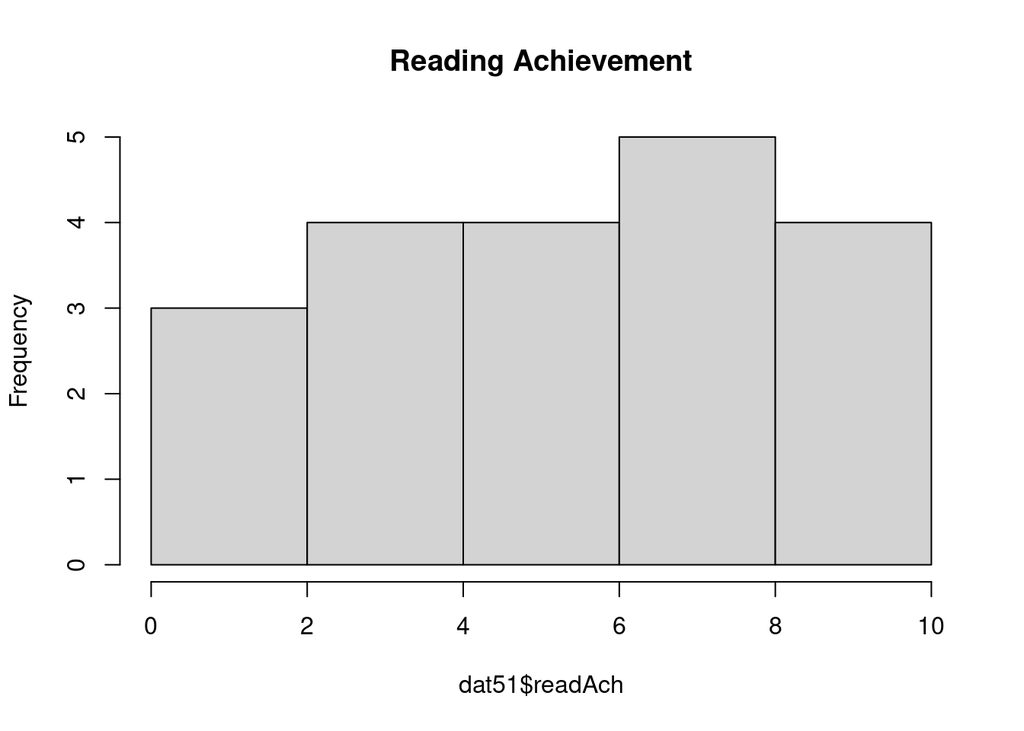

```r
hist(dat51$readAch, main = "Reading Achievement")
```

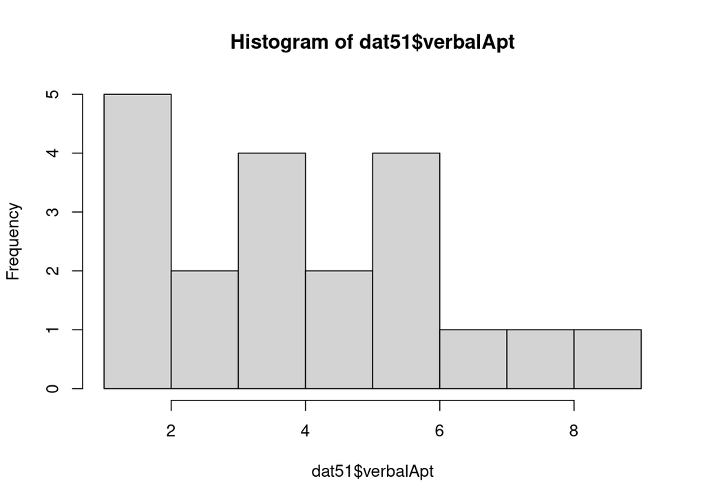

```r
hist(dat51$verbalApt)
```

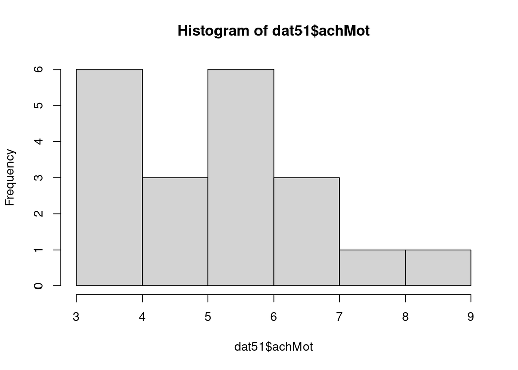

```r
hist(dat51$achMot)
```

```r
describe(dat51, fast = TRUE)
```

```
          vars  n mean   sd min max range   se
readAch      1 20 5.85 2.72   1  10     9 0.61
verbalApt    2 20 4.35 2.32   1   9     8 0.52
achMot       3 20 5.50 1.67   3   9     6 0.37
```

```r
n <- 10000
set.seed(1234)
x1 <- rnorm(n)
x2 <- rnorm(n)
y <- .5*x1 + .5*x2 + rnorm(n)
```

```r
cor(cbind(x1, x2, y))
```

[output not shown]

```r
mody.1 <- lm(y ~ x1)
mody.2 <- lm(y ~ x2)
mody.2 <- lm(y ~ x1 + x2)
htmlreg(list(mody.1, mody.2, mody.2),
        custom.model.names = c("y ~ x1", "y ~ x2", "y ~ x1 + x2") )
```

Statistical models

|  | y ~ x1 | y ~ x2 | y ~ x1 + x2 |
| --- | --- | --- | --- |
| (Intercept) | 0.00 | 0.00 | 0.00 |
|  | (0.01) | (0.01) | (0.01) |
| x1 | 0.49*** | 0.49*** | 0.49*** |
|  | (0.01) | (0.01) | (0.01) |
| x2 |  | 0.50*** | 0.50*** |
|  |  | (0.01) | (0.01) |
| R<sup>2</sup> | 0.16 | 0.33 | 0.33 |
| Adj. R<sup>2</sup> | 0.16 | 0.33 | 0.33 |
| Num. obs. | 10000 | 10000 | 10000 |

p < 0.001; p < 0.01; p < 0.05

```r
n <- 10000
set.seed(1234)
x1 <- rnorm(n)
x2 <- .5*x1 + rnorm(n)
y <- .5*x1 + .5*x2 + rnorm(n)
```

```r
cor(cbind(x1, x2, y))
```

[output not shown]

```r
mody.1 <- lm(y ~ x1)
mody.2 <- lm(y ~ x2)
mody.2 <- lm(y ~ x1 + x2)
htmlreg(list(mody.1, mody.2, mody.2),
        custom.model.names = c("y ~ x1", "y ~ x2", "y ~ x1 + x2"))
```

Statistical models

|  | y ~ x1 | y ~ x2 | y ~ x1 + x2 |
| --- | --- | --- | --- |
| (Intercept) | 0.00 | 0.00 | 0.00 |
|  | (0.01) | (0.01) | (0.01) |
| x1 | 0.74*** | 0.49*** | 0.49*** |
|  | (0.01) | (0.01) | (0.01) |
| x2 |  | 0.50*** | 0.50*** |
|  |  | (0.01) | (0.01) |
| R<sup>2</sup> | 0.30 | 0.44 | 0.44 |
| Adj. R<sup>2</sup> | 0.30 | 0.44 | 0.44 |
| Num. obs. | 10000 | 10000 | 10000 |

p < 0.001; p < 0.01; p < 0.05

### Simple Regression: Using Verbal Aptitude to Predict Reading Achievement

```r
mody.1 <- lm(readAch ~ verbalApt, data = dat51)
display(mody.1)
```

```
lm(formula = readAch ~ verbalApt, data = dat51)
            coef.est coef.se
(Intercept) 1.82     0.83
verbalApt   0.93     0.17
---
n = 20, k = 2
residual sd = 1.71, R-Squared = 0.63
```

### Simple Regression: Using Achievement Motivation to Predict Reading Achievement

```r
mody.2 <- lm(readAch ~ achMot, data = dat51)
display(mody.2)
```

```
lm(formula = readAch ~ achMot, data = dat51)
            coef.est coef.se
(Intercept) -0.22     1.62
achMot       1.10     0.28
---
n = 20, k = 2
residual sd = 2.05, R-Squared = 0.46
```

### Multiple Regression: Using Verbal Aptitude and Achievement Motivation to Predict Reading Achievement

```r
mody.12 <- lm(readAch ~ verbalApt + achMot, data = dat51)
display(mody.12)
```

```
lm(formula = readAch ~ verbalApt + achMot, data = dat51)
            coef.est coef.se
(Intercept) -0.47     1.19
verbalApt    0.70     0.18
achMot       0.59     0.24
---
n = 20, k = 3
residual sd = 1.51, R-Squared = 0.72
```

```r
htmlreg(list(mody.1, mody.2, mody.12))
```

Statistical models

|  | Model 1 | Model 2 | Model 3 |
| --- | --- | --- | --- |
| (Intercept) | 1.82* | -0.22 | -0.47 |
|  | (0.83) | (1.62) | (1.19) |
| verbalApt | 0.93*** |  | 0.70*** |
|  | (0.17) |  | (0.18) |
| achMot |  | 1.10** | 0.59* |
|  |  | (0.28) | (0.24) |
| R<sup>2</sup> | 0.63 | 0.46 | 0.72 |
| Adj. R<sup>2</sup> | 0.61 | 0.43 | 0.69 |
| Num. obs. | 20 | 20 | 20 |

p < 0.001; p < 0.01; p < 0.05